# k平均クラスタリング(k-means)

```python
%matplotlib inline
import numpy as np
import matplotlib.pyplot as plt
```

# データ生成

```python
def gen_data():
    x1 = np.random.normal(size=(100, 2)) + np.array([-5, -5])
    x2 = np.random.normal(size=(100, 2)) + np.array([5, -5])
    x3 = np.random.normal(size=(100, 2)) + np.array([0, 5])
    return np.vstack((x1, x2, x3))
```

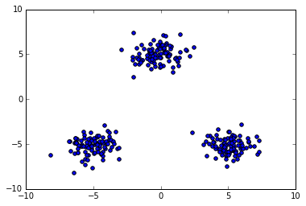

```python
#データ作成
X_train = gen_data()
#データ描画
plt.scatter(X_train[:, 0], X_train[:, 1])
```

## 学習

k-meansアルゴリズムは以下のとおりである

1) 各クラスタ中心の初期値を設定する

2) 各データ点に対して、各クラスタ中心との距離を計算し、最も距離が近いクラスタを割り当てる

3) 各クラスタの平均ベクトル（中心）を計算する

4) 収束するまで2, 3の処理を繰り返す

```python
def distance(x1, x2):
    return np.sum((x1 - x2)**2, axis=1)

n_clusters = 3
iter_max = 100

# 各クラスタ中心をランダムに初期化
centers = X_train[np.random.choice(len(X_train), n_clusters, replace=False)]

for _ in range(iter_max):
    prev_centers = np.copy(centers)
    D = np.zeros((len(X_train), n_clusters))
    # 各データ点に対して、各クラスタ中心との距離を計算
    for i, x in enumerate(X_train):
        D[i] = distance(x, centers)
    # 各データ点に、最も距離が近いクラスタを割り当
    cluster_index = np.argmin(D, axis=1)
    # 各クラスタの中心を計算
    for k in range(n_clusters):
        index_k = cluster_index == k
        centers[k] = np.mean(X_train[index_k], axis=0) #対象クラスターのデータを取得
    # 収束判定
    if np.allclose(prev_centers, centers):
        break
```

## クラスタリング結果

```python
def plt_result(X_train, centers, xx):
    #　データを可視化
    plt.scatter(X_train[:, 0], X_train[:, 1], c=y_pred, cmap='spring')
    # 中心を可視化
    plt.scatter(centers[:, 0], centers[:, 1], s=200, marker='+', lw=2, c='c', edgecolor="white")
    # 領域の可視化
    pred = np.empty(len(xx), dtype=int)
    for i, x in enumerate(xx):
        d = distance(x, centers)
        pred[i] = np.argmin(d)
    plt.contourf(xx0, xx1, pred.reshape(100, 100), alpha=0.2, cmap='spring')
```

```python
y_pred = np.empty(len(X_train), dtype=int)
for i, x in enumerate(X_train):
    d = distance(x, centers)
    y_pred[i] = np.argmin(d)
```

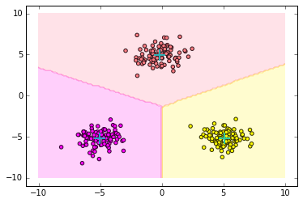

```python
xx0, xx1 = np.meshgrid(np.linspace(-10, 10, 100), np.linspace(-10, 10, 100))
xx = np.array([xx0, xx1]).reshape(2, -1).T

plt_result(X_train, centers, xx)
```

```python
from sklearn.cluster import KMeans
kmeans = KMeans(n_clusters=3, random_state=0).fit(X_train)
```

```python
print("labels: {}".format(kmeans.labels_))
print("cluster_centers: {}".format(kmeans.cluster_centers_))
kmeans.cluster_centers_
```

```
labels: [2 2 2 2 2 2 2 2 2 2 2 2 2 2 2 2 2 2 2 2 2 2 2 2 2 2 2 2 2 2 2 2 2 2 2 2 2
 2 2 2 2 2 2 2 2 2 2 2 2 2 2 2 2 2 2 2 2 2 2 2 2 2 2 2 2 2 2 2 2 2 2 2 2 2
 2 2 2 2 2 2 2 2 2 2 2 2 2 2 2 2 2 2 2 2 2 2 2 2 2 2 0 0 0 0 0 0 0 0 0 0 0
 0 0 0 0 0 0 0 0 0 0 0 0 0 0 0 0 0 0 0 0 0 0 0 0 0 0 0 0 0 0 0 0 0 0 0 0 0
 0 0 0 0 0 0 0 0 0 0 0 0 0 0 0 0 0 0 0 0 0 0 0 0 0 0 0 0 0 0 0 0 0 0 0 0 0
 0 0 0 0 0 0 0 0 0 0 0 0 0 0 0 1 1 1 1 1 1 1 1 1 1 1 1 1 1 1 1 1 1 1 1 1 1
 1 1 1 1 1 1 1 1 1 1 1 1 1 1 1 1 1 1 1 1 1 1 1 1 1 1 1 1 1 1 1 1 1 1 1 1 1
 1 1 1 1 1 1 1 1 1 1 1 1 1 1 1 1 1 1 1 1 1 1 1 1 1 1 1 1 1 1 1 1 1 1 1 1 1
 1 1 1 1]
cluster_centers: [[ 5.01537464 -5.0186465 ]
 [ 0.2126104   4.84431801]
 [-4.73643293 -4.99041391]]
```

```
array([[ 5.01537464, -5.0186465 ],
       [ 0.2126104 ,  4.84431801],
       [-4.73643293, -4.99041391]])
```

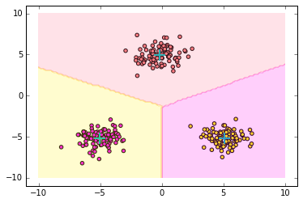

```python
plt_result(X_train, kmeans.cluster_centers_, xx)
```

# 考察

クラスタリングは、似たデータをブルーピングする際に利用される。  
knn法：教師あり学習  
k平均法:教師なし学習

クラスターの数は、決めるのはナレッジによるらしい。  
クラスターの数の決め方について調べて見ると、  
最適なクラスターの数を決める手法も存在するとのことだったのでそちらの調査も引き続きやっていきたいところだ。

やってみて感じたことが３つある。  
**・最終的なクラスターの中心点は、初期値に依存される**  
**・欠陥品や外れ値検出にも使えるのではないかと感じた。**  
例えば、クラスターの中心との距離を算出し、ある閾値を超えたときに異常と判断する、、、という風に使う。  
ある閾値を決める際には、統計的指標で決定づける。  
**・教師なし学習なので、人間が気づかないような特徴を見出す可能性もありそう。**  
例えば、歩行データの波形から個人識別ができそう。(その人自身の歩き方の癖がわかる)  
前進方向の波形はなんとなくSin波に近い波形を出したり。。。。  
靴の外側が他の部分に比べてすり減っている人は、波形が左右の方向によってたり。。。  
というのは、なんとなく予想は出来るが人間が考えうる仮説は限度があるので機械が特徴を見出してくれるかもしれないと思った。